# Cyclistic Bike-Share Analysis Case Study

### Data Source Description

For this analysis, we will use the past 12 months of **Cyclistic’s historical trip data**, made available by **Motivate International Inc.** under an open data license. This dataset contains detailed information about bike trips, including:

- **Trip start and end times**
- **Trip durations**
- **Start and end station names**
- **Bike types** (e.g., traditional, reclining, cargo)
- **User type** (casual rider vs. annual member)

Due to privacy regulations, no personally identifiable information (PII) is included in the dataset, meaning we cannot identify riders by name, credit card information, or location of residence. This ensures compliance with data privacy laws.

### Data Location and Organization

- The data is stored in **multiple CSV files**, each representing one month of trip data. These files will need to be loaded and combined to form a comprehensive dataset covering the entire 12-month period.
- Each CSV file is structured with the same format, containing columns for trip duration, start and end stations, user types, and bike type.

### Key Data Quality Considerations

- **Licensing, Privacy, Security**: The dataset is publicly available and does not contain sensitive information, ensuring compliance with privacy and security policies.
- **Credibility**: The data is provided by a reputable source, Motivate International Inc., which manages bike-share programs in various cities. This adds to its credibility and reliability for the purpose of this analysis.

### Data Integrity Checks

To ensure the integrity and reliability of the dataset, the following checks will be performed: - **Check for missing values**: Any missing or null values will be identified and handled appropriately (e.g., imputing, excluding). - **Duplicate entries**: Duplicate rows will be removed to avoid skewing the analysis. - **Consistency across files**: All monthly datasets will be checked for consistent column names and data types to ensure they can be properly merged.

### Data Preparation Tasks

1. **Download and Store Data**:
   - Download the 12 monthly CSV files and store them in a designated directory for analysis.
2. **Data Sorting and Filtering**:
   - Load the data into R, merge the files into one comprehensive dataset, and sort the data to ensure that it is clean and ready for analysis.
3. **Address Potential Bias**:
   - Since the data does not include information on where casual riders live or whether they have made multiple purchases, this may introduce bias in interpreting usage patterns.
   - The dataset focuses solely on bike trip information, so any external factors (e.g., weather, promotions) influencing bike usage are not included. This is a limitation to consider during analysis.
4. **Assess ROCCC (Reliability, Originality, Completeness, Consistency, Citedness)**:
   - **Reliability**: The data is reliable since it’s provided by an established company managing bike-share programs.
   - **Originality**: The dataset is original and specific to Cyclistic’s operations.
   - **Completeness**: The dataset spans 12 months, providing enough data to observe meaningful trends.
   - **Consistency**: Consistent formatting across months ensures smooth data merging.
   - **Citedness**: Motivate International Inc. is cited as the original source of the dataset.

### Deliverable

**Data Sources**: - **Source**: Historical bike trip data provided by Motivate International Inc. under public license.  
- **Format**: 12 monthly CSV files, each containing records of bike trips, user types, and related details.  
- **Key Variables**: - `ride_id`, `rideable_type` (e.g., traditional bike, electric bike) - `started_at` and `ended_at` (trip start and end times) - `start_station_name` and `end_station_name` (trip station details) - `member_casual` (user type: casual rider or annual member)

This dataset is comprehensive for analyzing user behavior and supporting our business task of comparing annual members and casual riders.

## Prepare

##### Install and Load Needed Packages

```r
library(dplyr)
library(tidyverse)
library(skimr)
```

```r
library(janitor)
library(lubridate)
```

```r
library(readr)
```

```r
library(ggplot2)
```

```r
library(tidyr)
```

## Combining and Standardizing Cyclistic Trip Data from Multiple CSV Files into a Single Data Frame

```r
# List of CSV file paths
csv_files <- list(
    "C:/Users/dangw/Desktop/Capstone_Project/Cyclistic_Case_Study/202408-divvy-tripdata.csv",
    "C:/Users/dangw/Desktop/Capstone_Project/Cyclistic_Case_Study/202407-divvy-tripdata.csv",
    "C:/Users/dangw/Desktop/Capstone_Project/Cyclistic_Case_Study/202406-divvy-tripdata.csv",
    "C:/Users/dangw/Desktop/Capstone_Project/Cyclistic_Case_Study/202405-divvy-tripdata.csv",
    "C:/Users/dangw/Desktop/Capstone_Project/Cyclistic_Case_Study/202404-divvy-tripdata.csv",
    "C:/Users/dangw/Desktop/Capstone_Project/Cyclistic_Case_Study/202403-divvy-tripdata.csv",
    "C:/Users/dangw/Desktop/Capstone_Project/Cyclistic_Case_Study/202402-divvy-tripdata.csv",
    "C:/Users/dangw/Desktop/Capstone_Project/Cyclistic_Case_Study/202401-divvy-tripdata.csv",
    "C:/Users/dangw/Desktop/Capstone_Project/Cyclistic_Case_Study/202312-divvy-tripdata.csv",
    "C:/Users/dangw/Desktop/Capstone_Project/Cyclistic_Case_Study/202311-divvy-tripdata.csv",
    "C:/Users/dangw/Desktop/Capstone_Project/Cyclistic_Case_Study/202310-divvy-tripdata.csv",
    "C:/Users/dangw/Desktop/Capstone_Project/Cyclistic_Case_Study/202309-divvy-tripdata.csv"
)

# Function to safely read a CSV file
read_csv_safe <- function(file) {
    tryCatch({
        read.csv(file, stringsAsFactors = FALSE, na.strings = c("", "NA"))  # Set stringsAsFactors=FALSE to avoid factor issues
    }, error = function(e) {
        message(paste("Error reading file:", file))
        return(NULL)  # Return NULL in case of an error
    })
}

# Read all CSV files into a list of data frames
datasets <- lapply(csv_files, read_csv_safe)
```

```r
# Remove any NULL entries (from files that couldn't be read)
datasets <- datasets[!sapply(datasets, is.null)]

# Find the set of all column names across all datasets
all_columns <- Reduce(union, lapply(datasets, colnames))

# Ensure all datasets have the same columns by adding missing columns with NA
datasets <- lapply(datasets, function(df) {
    # Standardize column names to lower case and trim whitespace to avoid mismatches
    colnames(df) <- tolower(trimws(colnames(df)))
    all_columns_standardized <- tolower(trimws(all_columns))

    missing_cols <- setdiff(all_columns_standardized, colnames(df))
    df[missing_cols] <- NA  # Add missing columns filled with NA
    df <- df[all_columns_standardized]   # Reorder columns to match the order of 'all_columns'
    return(df)
})

# Combine all datasets by row-binding them together
yearly_data <- do.call(rbind, datasets)
```

## Process

```r
# View the first few rows of the resulting dataset
head(yearly_data)
```

```
##            ride_id rideable_type started_at ended_at       start_station_name
## 1 BAA154388A869E64  classic_bike    35:14.4  48:24.4   State St & Randolph St
## 2 8752245932EFF67A electric_bike    33:14.0  55:23.9  Franklin St & Monroe St
## 3 44DDF9F57A9A161F  classic_bike    44:06.2  57:52.1  Franklin St & Monroe St
## 4 44AAAF069B0C78C3 electric_bike    47:11.9  56:33.3        Clark St & Elm St
## 5 77138D500A6B7B4B  classic_bike    34:20.6  46:29.3 Western Ave & Leland Ave
## 6 F6F581F31A9C9BC2 electric_bike    08:09.1  44:53.8        Clark St & Elm St
##   start_station_id               end_station_name end_station_id start_lat
## 1     TA1305000029            Wabash Ave & 9th St   TA1309000010  41.88462
## 2     TA1309000007        Damen Ave & Cortland St          13133  41.88032
## 3     TA1309000007              Clark St & Elm St   TA1307000039  41.88032
## 4     TA1307000039           McClurg Ct & Ohio St   TA1306000029  41.90297
## 5     TA1307000140 Ashland Ave & Belle Plaine Ave          13249  41.96640
## 6     TA1307000039   Stetson Ave & South Water St   TA1308000029  41.90297
##   start_lng  end_lat   end_lng member_casual  x
## 1 -87.62783 41.87077 -87.62573        member NA
## 2 -87.63519 41.91598 -87.67733        member NA
## 3 -87.63519 41.90297 -87.63128        member NA
## 4 -87.63128 41.89259 -87.61729        member NA
## 5 -87.68870 41.95606 -87.66884        casual NA
## 6 -87.63128 41.88683 -87.62232        casual NA
```

```r
#Statistical summary of data
summary(yearly_data)
```

```
##    ride_id          rideable_type       started_at          ended_at
##  Length:5699639     Length:5699639     Length:5699639     Length:5699639
##  Class :character   Class :character   Class :character   Class :character
##  Mode  :character   Mode  :character   Mode  :character   Mode  :character
##
##
##
##
##  start_station_name start_station_id   end_station_name   end_station_id
##  Length:5699639     Length:5699639     Length:5699639     Length:5699639
##  Class :character   Class :character   Class :character   Class :character
##  Mode  :character   Mode  :character   Mode  :character   Mode  :character
##
##
##
##
##    start_lat       start_lng         end_lat         end_lng
##  Min.   :41.64   Min.   :-87.94   Min.   :16.06   Min.   :-144.05
##  1st Qu.:41.88   1st Qu.:-87.66   1st Qu.:41.88   1st Qu.: -87.66
##  Median :41.90   Median :-87.64   Median :41.90   Median : -87.64
##  Mean   :41.90   Mean   :-87.65   Mean   :41.90   Mean   : -87.65
##  3rd Qu.:41.93   3rd Qu.:-87.63   3rd Qu.:41.93   3rd Qu.: -87.63
##  Max.   :42.07   Max.   :-87.52   Max.   :87.96   Max.   : -79.02
##                                   NA's   :7526    NA's   :7526
##  member_casual         x
##  Length:5699639     Mode:logical
##  Class :character   NA's:5699639
##  Mode  :character
##
##
##
##
```

```r
# Check the structure of the new dataset and look for inconguencies
str(yearly_data)
```

```
## 'data.frame':    5699639 obs. of  14 variables:
##  $ ride_id           : chr  "BAA154388A869E64" "8752245932EFF67A" "44DDF9F57A9A161F" "44AAAF069B0C78C3" ...
##  $ rideable_type     : chr  "classic_bike" "electric_bike" "classic_bike" "electric_bike" ...
##  $ started_at        : chr  "35:14.4" "33:14.0" "44:06.2" "47:11.9" ...
##  $ ended_at          : chr  "48:24.4" "55:23.9" "57:52.1" "56:33.3" ...
##  $ start_station_name: chr  "State St & Randolph St" "Franklin St & Monroe St" "Franklin St & Monroe St" "Clark St & Elm St" ...
##  $ start_station_id  : chr  "TA1305000029" "TA1309000007" "TA1309000007" "TA1307000039" ...
##  $ end_station_name  : chr  "Wabash Ave & 9th St" "Damen Ave & Cortland St" "Clark St & Elm St" "McClurg Ct & Ohio St" ...
##  $ end_station_id    : chr  "TA1309000010" "13133" "TA1307000039" "TA1306000029" ...
##  $ start_lat         : num  41.9 41.9 41.9 41.9 42 ...
##  $ start_lng         : num  -87.6 -87.6 -87.6 -87.6 -87.7 ...
##  $ end_lat           : num  41.9 41.9 41.9 41.9 42 ...
##  $ end_lng           : num  -87.6 -87.7 -87.6 -87.6 -87.7 ...
##  $ member_casual     : chr  "member" "member" "member" "member" ...
##  $ x                 : logi  NA NA NA NA NA NA ...
```

```r
#List of column names
colnames(yearly_data)
```

```
##  [1] "ride_id"            "rideable_type"      "started_at"
##  [4] "ended_at"           "start_station_name" "start_station_id"
##  [7] "end_station_name"   "end_station_id"     "start_lat"
## [10] "start_lng"          "end_lat"            "end_lng"
## [13] "member_casual"      "x"
```

```r
#number of rows in dataset?
nrow(yearly_data)
```

```
## [1] 5699639
```

```r
#Dimensions of the dataset?
dim(yearly_data)
```

```
## [1] 5699639      14
```

## Cleaning

```r
#Remove columns that are not needed

yearly_data <- yearly_data %>%
  select(-starts_with("x"), -starts_with("start_lat"), -starts_with("start_lng"),
         -starts_with("end_lat"), -starts_with("end_lng"))
```

```r
#Check the first few rows of the cleaned dataset
head(yearly_data)
```

```
##            ride_id rideable_type started_at ended_at       start_station_name
## 1 BAA154388A869E64  classic_bike    35:14.4  48:24.4   State St & Randolph St
## 2 8752245932EFF67A electric_bike    33:14.0  55:23.9  Franklin St & Monroe St
## 3 44DDF9F57A9A161F  classic_bike    44:06.2  57:52.1  Franklin St & Monroe St
## 4 44AAAF069B0C78C3 electric_bike    47:11.9  56:33.3        Clark St & Elm St
## 5 77138D500A6B7B4B  classic_bike    34:20.6  46:29.3 Western Ave & Leland Ave
## 6 F6F581F31A9C9BC2 electric_bike    08:09.1  44:53.8        Clark St & Elm St
##   start_station_id               end_station_name end_station_id member_casual
## 1     TA1305000029            Wabash Ave & 9th St   TA1309000010        member
## 2     TA1309000007        Damen Ave & Cortland St          13133        member
## 3     TA1309000007              Clark St & Elm St   TA1307000039        member
## 4     TA1307000039           McClurg Ct & Ohio St   TA1306000029        member
## 5     TA1307000140 Ashland Ave & Belle Plaine Ave          13249        casual
## 6     TA1307000039   Stetson Ave & South Water St   TA1308000029        casual
```

```r
#Check the columns of the cleaned dataset
colnames(yearly_data)
```

```
## [1] "ride_id"            "rideable_type"      "started_at"
## [4] "ended_at"           "start_station_name" "start_station_id"
## [7] "end_station_name"   "end_station_id"     "member_casual"
```

```r
# Remove rows with any NA values
yearly_data<- drop_na(yearly_data)
```

```r
# Check the structure of the updated dataset
str(yearly_data)
```

```
## 'data.frame':    4197617 obs. of  9 variables:
##  $ ride_id           : chr  "BAA154388A869E64" "8752245932EFF67A" "44DDF9F57A9A161F" "44AAAF069B0C78C3" ...
##  $ rideable_type     : chr  "classic_bike" "electric_bike" "classic_bike" "electric_bike" ...
##  $ started_at        : chr  "35:14.4" "33:14.0" "44:06.2" "47:11.9" ...
##  $ ended_at          : chr  "48:24.4" "55:23.9" "57:52.1" "56:33.3" ...
##  $ start_station_name: chr  "State St & Randolph St" "Franklin St & Monroe St" "Franklin St & Monroe St" "Clark St & Elm St" ...
##  $ start_station_id  : chr  "TA1305000029" "TA1309000007" "TA1309000007" "TA1307000039" ...
##  $ end_station_name  : chr  "Wabash Ave & 9th St" "Damen Ave & Cortland St" "Clark St & Elm St" "McClurg Ct & Ohio St" ...
##  $ end_station_id    : chr  "TA1309000010" "13133" "TA1307000039" "TA1306000029" ...
##  $ member_casual     : chr  "member" "member" "member" "member" ...
```

## Understanding the Gaps: Acknowledging Limitations in Our Findings

Limitation in Findings: During the data pprocessing phase, rows with missing or invalid date and time information (started_at and ended_at columns) were removed from the dataset. Although this step ensured data integrity, it may have resulted in the exclusion of valid trips that were not properly recorded in the source data. As a consequence, the analysis may not reflect the full usage patterns, particularly in cases where incomplete trip data was significant. This limitation should be considered when interpreting temporal trends, as some edge cases might have been missed. Addressing this limitation would involve ensuring that future data collection processes include consistent and accurate date-time recordings.

```r
# Parse 'started_at' and 'ended_at' safely and filter out invalid dates
yearly_data$started_at <- ymd_hms(yearly_data$started_at, tz = "UTC", quiet = TRUE)
yearly_data$ended_at <- ymd_hms(yearly_data$ended_at, tz = "UTC", quiet = TRUE)
yearly_data <- yearly_data %>% filter(!is.na(started_at) & !is.na(ended_at))

# Filter dates within the expected range
yearly_data <- yearly_data %>%
  filter(as.Date(started_at) >= as.Date("2023-09-01") & as.Date(started_at) <= as.Date("2024-08-31"))

# Add columns for date parts and calculate ride length
yearly_data <- yearly_data %>%
  mutate(date = as.Date(started_at),
         month = format(date, "%m"),
         day = format(date, "%d"),
         year = format(date, "%Y"),
         day_of_week = format(date, "%A"),
         ride_length = as.numeric(difftime(ended_at, started_at, units = "secs")))

# Check the result
head(yearly_data)
```

```
##            ride_id rideable_type          started_at            ended_at
## 1 9F1B72A05AEC1030 electric_bike 2024-05-21 00:08:40 2024-05-21 00:08:44
## 2 079A418333193337  classic_bike 2024-05-21 00:19:22 2024-05-21 00:19:26
## 3 EBB6F365D02FD818  classic_bike 2024-05-21 00:14:48 2024-05-21 00:15:18
## 4 0E560C50554ED728  classic_bike 2024-05-21 00:14:48 2024-05-21 00:15:18
## 5 225F742ED1F8013B  classic_bike 2024-05-21 00:14:47 2024-05-21 00:15:18
## 6 EC2CB4F841F5A415  classic_bike 2024-05-21 00:20:45 2024-05-21 00:20:53
##          start_station_name start_station_id            end_station_name
## 1    State St & Randolph St     TA1305000029   Columbus Dr & Randolph St
## 2 Chicago Ave & Sheridan Rd             E008 Sheridan Rd & Noyes St (NU)
## 3   Streeter Dr & Grand Ave            13022           Adler Planetarium
## 4   Streeter Dr & Grand Ave            13022           Adler Planetarium
## 5   Streeter Dr & Grand Ave            13022           Adler Planetarium
## 6 Halsted St & Clybourn Ave              331 Dearborn Pkwy & Delaware Pl
##   end_station_id member_casual       date month day year day_of_week
## 1          13263        member 2024-05-21    05  21 2024     Tuesday
## 2            604        casual 2024-05-21    05  21 2024     Tuesday
## 3          13431        casual 2024-05-21    05  21 2024     Tuesday
## 4          13431        casual 2024-05-21    05  21 2024     Tuesday
## 5          13431        casual 2024-05-21    05  21 2024     Tuesday
## 6   TA1307000128        member 2024-05-21    05  21 2024     Tuesday
##   ride_length
## 1           4
## 2           4
## 3          30
## 4          30
## 5          31
## 6           8
```

```r
# Calculate the 'ride_length' by finding the difference between 'ended_at' and 'started_at' timestamps.
yearly_data$ride_length <- difftime(yearly_data$ended_at, yearly_data$started_at)
str(yearly_data)
```

```
## 'data.frame':    75795 obs. of  15 variables:
##  $ ride_id           : chr  "9F1B72A05AEC1030" "079A418333193337" "EBB6F365D02FD818" "0E560C50554ED728" ...
##  $ rideable_type     : chr  "electric_bike" "classic_bike" "classic_bike" "classic_bike" ...
##  $ started_at        : POSIXct, format: "2024-05-21 00:08:40" "2024-05-21 00:19:22" ...
##  $ ended_at          : POSIXct, format: "2024-05-21 00:08:44" "2024-05-21 00:19:26" ...
##  $ start_station_name: chr  "State St & Randolph St" "Chicago Ave & Sheridan Rd" "Streeter Dr & Grand Ave" "Streeter Dr & Grand Ave" ...
##  $ start_station_id  : chr  "TA1305000029" "E008" "13022" "13022" ...
##  $ end_station_name  : chr  "Columbus Dr & Randolph St" "Sheridan Rd & Noyes St (NU)" "Adler Planetarium" "Adler Planetarium" ...
##  $ end_station_id    : chr  "13263" "604" "13431" "13431" ...
##  $ member_casual     : chr  "member" "casual" "casual" "casual" ...
##  $ date              : Date, format: "2024-05-21" "2024-05-21" ...
##  $ month             : chr  "05" "05" "05" "05" ...
##  $ day               : chr  "21" "21" "21" "21" ...
##  $ year              : chr  "2024" "2024" "2024" "2024" ...
##  $ day_of_week       : chr  "Tuesday" "Tuesday" "Tuesday" "Tuesday" ...
##  $ ride_length       : 'difftime' num  4 4 30 30 ...
##   ..- attr(*, "units")= chr "secs"
```

```r
# Check if the 'ride_length' column is a factor before converting it to numeric.
is.factor(yearly_data$ride_length)
```

```
## [1] FALSE
```

```r
# Convert the 'ride_length' column from factor (or character) to numeric.
yearly_data$ride_length <- as.numeric(as.character(yearly_data$ride_length))

# Check if the 'ride_length' column is now numeric.
is.numeric(yearly_data$ride_length)
```

```
## [1] TRUE
```

```r
# Filter out entries with ride length less than zero
yearly_data_v2 <- yearly_data %>%
  filter(ride_length >= 0)

# Check the result
head(yearly_data)
```

```
##            ride_id rideable_type          started_at            ended_at
## 1 9F1B72A05AEC1030 electric_bike 2024-05-21 00:08:40 2024-05-21 00:08:44
## 2 079A418333193337  classic_bike 2024-05-21 00:19:22 2024-05-21 00:19:26
## 3 EBB6F365D02FD818  classic_bike 2024-05-21 00:14:48 2024-05-21 00:15:18
## 4 0E560C50554ED728  classic_bike 2024-05-21 00:14:48 2024-05-21 00:15:18
## 5 225F742ED1F8013B  classic_bike 2024-05-21 00:14:47 2024-05-21 00:15:18
## 6 EC2CB4F841F5A415  classic_bike 2024-05-21 00:20:45 2024-05-21 00:20:53
##          start_station_name start_station_id            end_station_name
## 1    State St & Randolph St     TA1305000029   Columbus Dr & Randolph St
## 2 Chicago Ave & Sheridan Rd             E008 Sheridan Rd & Noyes St (NU)
## 3   Streeter Dr & Grand Ave            13022           Adler Planetarium
## 4   Streeter Dr & Grand Ave            13022           Adler Planetarium
## 5   Streeter Dr & Grand Ave            13022           Adler Planetarium
## 6 Halsted St & Clybourn Ave              331 Dearborn Pkwy & Delaware Pl
##   end_station_id member_casual       date month day year day_of_week
## 1          13263        member 2024-05-21    05  21 2024     Tuesday
## 2            604        casual 2024-05-21    05  21 2024     Tuesday
## 3          13431        casual 2024-05-21    05  21 2024     Tuesday
## 4          13431        casual 2024-05-21    05  21 2024     Tuesday
## 5          13431        casual 2024-05-21    05  21 2024     Tuesday
## 6   TA1307000128        member 2024-05-21    05  21 2024     Tuesday
##   ride_length
## 1           4
## 2           4
## 3          30
## 4          30
## 5          31
## 6           8
```

```r
# Calculate the average ride length for the cleaned dataset 'yearly_data'.
mean(yearly_data_v2$ride_length)
```

```
## [1] 114608.8
```

```r
# Calculate the median ride length for the cleaned dataset 'yearly_data'.
median(yearly_data_v2$ride_length)
```

```
## [1] 10
```

```r
#longest ride
max(yearly_data_v2$ride_length)
```

```
## [1] 31622427
```

```r
#shortest ride
min(yearly_data_v2$ride_length)
```

```
## [1] 0
```

```r
# Generate a summary of the 'ride_length' column for the cleaned dataset 'yearly_data_v2'.
# The summary includes the minimum, 1st quartile, median, mean, 3rd quartile, and maximum values
summary(yearly_data_v2$ride_length)
```

```
##     Min.  1st Qu.   Median     Mean  3rd Qu.     Max.
##        0        6       10   114609       17 31622427
```

```r
# Calculate the average ride length for each user type ('member' or 'casual') in the 'yearly_data_v2' dataset.
aggregate(yearly_data_v2$ride_length ~ yearly_data_v2$member_casual, FUN = mean)
```

```
##   yearly_data_v2$member_casual yearly_data_v2$ride_length
## 1                       casual                  193037.18
## 2                       member                   74009.55
```

```r
# Calculate the median ride length for each user type ('member' or 'casual') in the 'yearly_data_v2' dataset.
aggregate(yearly_data_v2$ride_length ~ yearly_data_v2$member_casual, FUN = median)
```

```
##   yearly_data_v2$member_casual yearly_data_v2$ride_length
## 1                       casual                         13
## 2                       member                          8
```

```r
# Calculate the maximum ride length for each user type ('member' or 'casual') in the 'yearly_data_v2' dataset.
aggregate(yearly_data_v2$ride_length ~ yearly_data_v2$member_casual, FUN = max)
```

```
##   yearly_data_v2$member_casual yearly_data_v2$ride_length
## 1                       casual                   31622427
## 2                       member                   31622042
```

```r
# Calculate the minimum ride length for each user type ('member' or 'casual') in the 'yearly_data_v2' dataset.
aggregate(yearly_data_v2$ride_length ~ yearly_data_v2$member_casual, FUN = min)
```

```
##   yearly_data_v2$member_casual yearly_data_v2$ride_length
## 1                       casual                          0
## 2                       member                          0
```

```r
# Calculate the average ride length for each combination of user type ('member' or 'casual')
# and day of the week in the 'yearly_data_v2' dataset.
aggregate(yearly_data_v2$ride_length ~ yearly_data_v2$member_casual + yearly_data_v2$day_of_week, FUN = mean)
```

```
##    yearly_data_v2$member_casual yearly_data_v2$day_of_week
## 1                        casual                     Friday
## 2                        member                     Friday
## 3                        casual                     Monday
## 4                        member                     Monday
## 5                        casual                     Sunday
## 6                        member                     Sunday
## 7                        casual                   Thursday
## 8                        member                   Thursday
## 9                        casual                    Tuesday
## 10                       member                    Tuesday
## 11                       casual                  Wednesday
## 12                       member                  Wednesday
##    yearly_data_v2$ride_length
## 1                    94355.47
## 2                    49991.75
## 3                    28230.43
## 4                   102582.56
## 5                   185723.22
## 6                    24450.94
## 7                   266396.98
## 8                    61499.46
## 9                   285517.09
## 10                  127636.98
## 11                  188965.12
## 12                   91071.43
```

```r
# Reorder the 'day_of_week' column in 'yearly_data_v2' so that the days are in chronological order,
# starting from Sunday through Saturday.
yearly_data_v2$day_of_week <- ordered(yearly_data_v2$day_of_week, levels=c("Sunday", "Monday", "Tuesday", "Wednesday", "Thursday", "Friday", "Saturday"))
```

```r
# get the average ride time by each day for members vs casual users
aggregate(yearly_data_v2$ride_length ~ yearly_data_v2$member_casual + yearly_data_v2$day_of_week, FUN = mean)
```

```
##    yearly_data_v2$member_casual yearly_data_v2$day_of_week
## 1                        casual                     Sunday
## 2                        member                     Sunday
## 3                        casual                     Monday
## 4                        member                     Monday
## 5                        casual                    Tuesday
## 6                        member                    Tuesday
## 7                        casual                  Wednesday
## 8                        member                  Wednesday
## 9                        casual                   Thursday
## 10                       member                   Thursday
## 11                       casual                     Friday
## 12                       member                     Friday
##    yearly_data_v2$ride_length
## 1                   185723.22
## 2                    24450.94
## 3                    28230.43
## 4                   102582.56
## 5                   285517.09
## 6                   127636.98
## 7                   188965.12
## 8                    91071.43
## 9                   266396.98
## 10                   61499.46
## 11                   94355.47
## 12                   49991.75
```

```r
# Add a 'weekday' column indicating the day of the week when the ride started,
# and group the data by user type ('member' or 'casual') and weekday.
yearly_data_v2 %>%
  mutate(weekday = wday(started_at, label = TRUE)) %>%  # Create a new 'weekday' column using the 'started_at' timestamp, with day labels
  group_by(member_casual, weekday) %>%  # Group by user type and day of the week
  summarise(number_of_rides = n(),  # Count the number of rides for each group
            average_duration = mean(ride_length)) %>%  # Calculate the average ride length for each group
  arrange(member_casual, weekday)  # Arrange the results by user type and day of the week
```

```
## # A tibble: 12 × 4
## # Groups:   member_casual [2]
##    member_casual weekday number_of_rides average_duration
##    <chr>         <ord>             <int>            <dbl>
##  1 casual        Sun                2208          185723.
##  2 casual        Mon                1121           28230.
##  3 casual        Tue                5081          285517.
##  4 casual        Wed               12552          188965.
##  5 casual        Thu                1539          266397.
##  6 casual        Fri                3352           94355.
##  7 member        Sun               10329           24451.
##  8 member        Mon                2158          102583.
##  9 member        Tue                8401          127637.
## 10 member        Wed               15974           91071.
## 11 member        Thu                3590           61499.
## 12 member        Fri                9490           49992.
```

# Share

### Number of Rides by User Type and Day of the Week

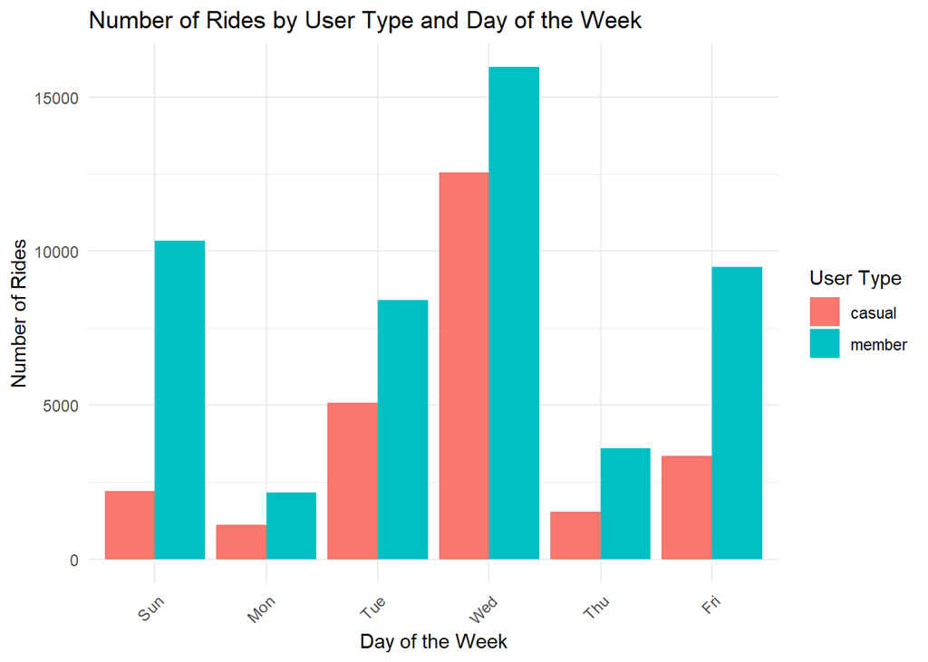

```r
# Add a 'weekday' column, group by user type and weekday, then calculate summary statistics
yearly_data_v2 %>%
  mutate(weekday = wday(started_at, label = TRUE)) %>%  # Create a new 'weekday' column from the 'started_at' timestamp with day labels
  group_by(member_casual, weekday) %>%  # Group the data by user type ('member' or 'casual') and day of the week
  summarise(number_of_rides = n(),  # Count the total number of rides for each group
            average_duration = mean(ride_length)) %>%  # Calculate the mean ride length for each group
  arrange(member_casual, weekday) %>%  # Arrange the results by user type and weekday

  # Create a bar chart showing the number of rides for each user type and day of the week
  ggplot(aes(x = weekday, y = number_of_rides, fill = member_casual)) +
  geom_col(position = "dodge") +  # Use geom_col() to create a bar chart with side-by-side bars for each user type

  # Add labels and a title to the plot
  labs(title = "Number of Rides by User Type and Day of the Week",
       x = "Day of the Week",
       y = "Number of Rides",
       fill = "User Type") +  # Label the legend as 'User Type'

  # Apply a minimal theme for a clean look
  theme_minimal() +

  # Rotate x-axis labels for better readability
  theme(axis.text.x = element_text(angle = 45, hjust = 1))
```

## Conclusion

The bar chart illustrates the **number of rides by user type** (casual vs. member) across the **days of the week**. Based on the visualized data: